# ML practice 3: Feature Selection

Сегодня мы поговорим о том, какие методы существуют для выбора предикторов для включения в модель.

### Данные

В качестве примера используем данные про цены на жилье в Бостоне (снова)

```r
library(MASS)
#?Boston

library(ggplot2)
library(dplyr)
```

- `crim` per capita crime rate by town
- `zn` proportion of residential land zoned for lots over 25,000 sq.ft
- `indus` proportion of non-retail business acres per town
- `chas` Charles River dummy variable (= 1 if tract bounds river; 0 otherwise).
- `nox` nitrogen oxides concentration (parts per 10 million).
- `rm` average number of rooms per dwelling.
- `age` proportion of owner-occupied units built prior to 1940.
- `dis` weighted mean of distances to five Boston employment centres.
- `rad` index of accessibility to radial highways.
- `tax` full-value property-tax rate per $10,000.
- `ptratio` pupil-teacher ratio by town.
- `black` 1000(Bk - 0.63)^2 where Bk is the proportion of blacks by town.
- `lstat` lower status of the population (percent).
- `medv` median value of owner-occupied homes in $1000s.

```r
data(Boston)
pander::pandoc.table(head(Boston), split.tables=Inf)
```

| crim | zn | indus | chas | nox | rm | age | dis | rad | tax | ptratio | black | lstat | medv |
| --- | --- | --- | --- | --- | --- | --- | --- | --- | --- | --- | --- | --- | --- |
| 0.00632 | 18 | 2.31 | 0 | 0.538 | 6.575 | 65.2 | 4.09 | 1 | 296 | 15.3 | 396.9 | 4.98 | 24 |
| 0.02731 | 0 | 7.07 | 0 | 0.469 | 6.421 | 78.9 | 4.967 | 2 | 242 | 17.8 | 396.9 | 9.14 | 21.6 |
| 0.02729 | 0 | 7.07 | 0 | 0.469 | 7.185 | 61.1 | 4.967 | 2 | 242 | 17.8 | 392.8 | 4.03 | 34.7 |
| 0.03237 | 0 | 2.18 | 0 | 0.458 | 6.998 | 45.8 | 6.062 | 3 | 222 | 18.7 | 394.6 | 2.94 | 33.4 |
| 0.06905 | 0 | 2.18 | 0 | 0.458 | 7.147 | 54.2 | 6.062 | 3 | 222 | 18.7 | 396.9 | 5.33 | 36.2 |
| 0.02985 | 0 | 2.18 | 0 | 0.458 | 6.43 | 58.7 | 6.062 | 3 | 222 | 18.7 | 394.1 | 5.21 | 28.7 |

Мы продолжаем использовать пакет `caret` ([подробнее](https://topepo.github.io/caret/feature-selection-overview.html))

```r
library(caret)
```

### Обучающая и тестовая выборки

Отделим 20% от датасета. Как обычно, эта часть не будет использоваться для обучения модели, но на ней мы будем проверять (тестировать), насколько хороша наша модель.

```r
set.seed(54321)
Boston.test.ind = createDataPartition(Boston$medv, p = 0.2, list = F)
Boston.test = Boston[Boston.test.ind,]
Boston.train = Boston[-Boston.test.ind,]
```

## Отбор признаков (Feature Selection)

- Зачем нужно выбирать, какие переменные включить в модель? Почему бы не использовать все?

Некоторые алгоритмы машинного обучения уже построены так, что отбирают только часть признаков. Например, деревья решений

```r
library(partykit)
```

[figure not shown]

```r
modelTree <- ctree(medv~., data = Boston.train)
plot(modelTree, digits = 2, type ="simple")
```

- Какие переменные не используются в модели?
- Какую долю от общего числа переменных составляют переменные, включенные в итоговую модель?

Другие алгоритмы строят модель по всем доступным переменным. Например:

```r
lm.fit<-lm(medv~., data = Boston.train)
summary(lm.fit)
```

```
##
## Call:
## lm(formula = medv ~ ., data = Boston.train)
##
## Residuals:
##      Min       1Q   Median       3Q      Max
## -16.0562  -2.5943  -0.6246   1.6235  24.9423
##
## Coefficients:
##               Estimate Std. Error t value Pr(>|t|)
## (Intercept)  35.837561   5.532087   6.478 2.81e-10 ***
## crim         -0.139932   0.036851  -3.797 0.000170 ***
## zn            0.049122   0.014517   3.384 0.000788 ***
## indus         0.039226   0.067539   0.581 0.561716
## chas          2.772422   0.911918   3.040 0.002524 **
## nox         -16.644405   4.175224  -3.986 8.01e-05 ***
## rm            3.614432   0.450735   8.019 1.26e-14 ***
## age           0.007317   0.014659   0.499 0.617945
## dis          -1.441344   0.224532  -6.419 3.99e-10 ***
## rad           0.306800   0.073621   4.167 3.80e-05 ***
## tax          -0.011904   0.004156  -2.864 0.004405 **
## ptratio      -0.908024   0.142741  -6.361 5.62e-10 ***
## black         0.010149   0.002952   3.438 0.000648 ***
## lstat        -0.607631   0.057265 -10.611  < 2e-16 ***
## ---
## Signif. codes:  0 '***' 0.001 '**' 0.01 '*' 0.05 '.' 0.1 ' ' 1
##
## Residual standard error: 4.655 on 389 degrees of freedom
## Multiple R-squared:  0.7503, Adjusted R-squared:  0.742
## F-statistic: 89.93 on 13 and 389 DF,  p-value: < 2.2e-16
```

- К какому типу вы отнесете логистическую регрессию?

### Методы отбора признаков

В целом методы отбора признаков можно разделить на три группы

- добавление / удаление признаков и выбор модели с лучшей оценкой качества (т.е. построение нескольких моделей и сравнение их между собой)
  - Recursive Feature Elimination
  - Genetic Algorithms
  - Simulated Annealing
- оценивание важности каждой из переменных по-отдельности (например, влияния ее на предсказываемую переменную), вне рамок модели
- встроенные методы – алгоритм устроен таким образом, что отбирает часть переменных (деревья, регрессия с регуляризацией)

Оценим **значимость** признаков согласно модели (например, для линейной регрессии по всем переменным)

```r
model <- train(medv~., data=Boston.train, method="lm")
importance <- varImp(model, scale=FALSE)
print(importance)
```

```
## lm variable importance
##
##         Overall
## lstat   10.6109
## rm       8.0190
## dis      6.4193
## ptratio  6.3614
## rad      4.1673
## nox      3.9865
## crim     3.7973
## black    3.4384
## zn       3.3837
## chas     3.0402
## tax      2.8644
## indus    0.5808
## age      0.4992
```

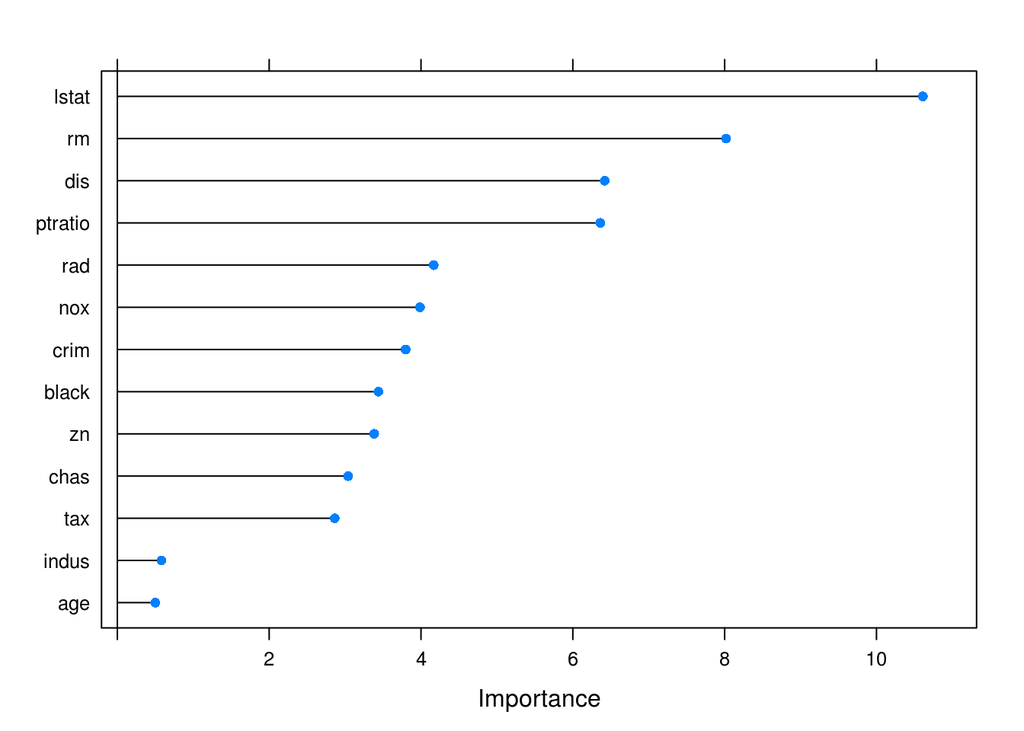

```r
plot(importance)
```

```r
summary(model)
```

```
##
## Call:
## lm(formula = .outcome ~ ., data = dat)
##
## Residuals:
##      Min       1Q   Median       3Q      Max
## -16.0562  -2.5943  -0.6246   1.6235  24.9423
##
## Coefficients:
##               Estimate Std. Error t value Pr(>|t|)
## (Intercept)  35.837561   5.532087   6.478 2.81e-10 ***
## crim         -0.139932   0.036851  -3.797 0.000170 ***
## zn            0.049122   0.014517   3.384 0.000788 ***
## indus         0.039226   0.067539   0.581 0.561716
## chas          2.772422   0.911918   3.040 0.002524 **
## nox         -16.644405   4.175224  -3.986 8.01e-05 ***
## rm            3.614432   0.450735   8.019 1.26e-14 ***
## age           0.007317   0.014659   0.499 0.617945
## dis          -1.441344   0.224532  -6.419 3.99e-10 ***
## rad           0.306800   0.073621   4.167 3.80e-05 ***
## tax          -0.011904   0.004156  -2.864 0.004405 **
## ptratio      -0.908024   0.142741  -6.361 5.62e-10 ***
## black         0.010149   0.002952   3.438 0.000648 ***
## lstat        -0.607631   0.057265 -10.611  < 2e-16 ***
## ---
## Signif. codes:  0 '***' 0.001 '**' 0.01 '*' 0.05 '.' 0.1 ' ' 1
##
## Residual standard error: 4.655 on 389 degrees of freedom
## Multiple R-squared:  0.7503, Adjusted R-squared:  0.742
## F-statistic: 89.93 on 13 and 389 DF,  p-value: < 2.2e-16
```

Для разных моделей значимость признаков оценивается по-разному. Для линейной регрессии значимость признака – это модуль значения t-критерия. Подробнее для других моделей можно посмотреть в справке функции `varImp()` (пакет caret)

- Какая переменная наиболее значима?

### Recursive Feature Elimination (RFE)

Алгоритм RFE работает следующим образом:

1. Построение модели по всем переменным (признакам)
2. Вычисление оценки качества модели
3. Упорядочение переменных согласно их значимости для модели (поочередно выкидываем одну переменную и смотрим, в каком случае предсказание лучше)
4. Удаление наименее значимой переменной
5. Построение модели по новому (сокращенному) набору переменных. Повторение шагов 2-4
6. Выбор лучшей модели (и лучшего набора признаков соответственно)

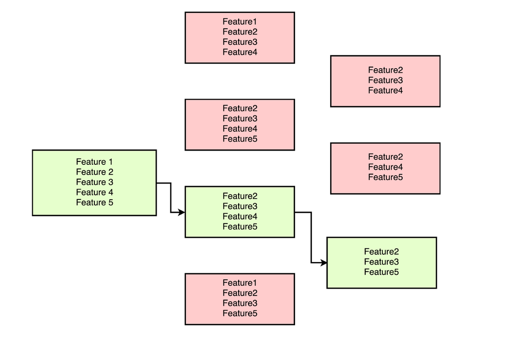

Как обычно, чтобы избежать влияния конкретного разбиение на тестовую-обучающую, используем кросс-валидацию.

Зададим параметры кросс-валидации

```r
control <- rfeControl(functions=lmFuncs, method="cv", number=10)
```

Запустим алгоритм RFE

```r
set.seed(10)
results <- rfe(x = dplyr::select(Boston.train, -medv),
               y= Boston.train$medv,
               sizes=c(1:13),
               rfeControl=control)
```

Результат:

```r
results
```

```
##
## Recursive feature selection
##
## Outer resampling method: Cross-Validated (10 fold)
##
## Resampling performance over subset size:
##
##  Variables  RMSE Rsquared   MAE RMSESD RsquaredSD  MAESD Selected
##          1 8.214   0.2140 6.002 1.2875    0.10667 0.7955
##          2 6.309   0.5388 4.317 1.2485    0.11963 0.5851
##          3 6.161   0.5627 4.278 1.2629    0.11764 0.6156
##          4 6.125   0.5684 4.240 1.2349    0.11629 0.5717
##          5 5.647   0.6252 3.949 1.2408    0.10659 0.5728
##          6 4.893   0.7196 3.511 0.7259    0.05977 0.3798
##          7 4.892   0.7201 3.541 0.7323    0.06089 0.3899
##          8 4.819   0.7284 3.505 0.7546    0.05919 0.4327
##          9 4.804   0.7322 3.472 0.7767    0.05814 0.4315
##         10 4.801   0.7345 3.485 0.8201    0.05882 0.4486
##         11 4.838   0.7333 3.507 0.8422    0.05935 0.4710
##         12 4.748   0.7424 3.426 0.8377    0.05713 0.4531
##         13 4.710   0.7453 3.392 0.8317    0.05518 0.4234        *
##
## The top 5 variables (out of 13):
##    nox, rm, chas, dis, ptratio
```

Сравнение моделей:

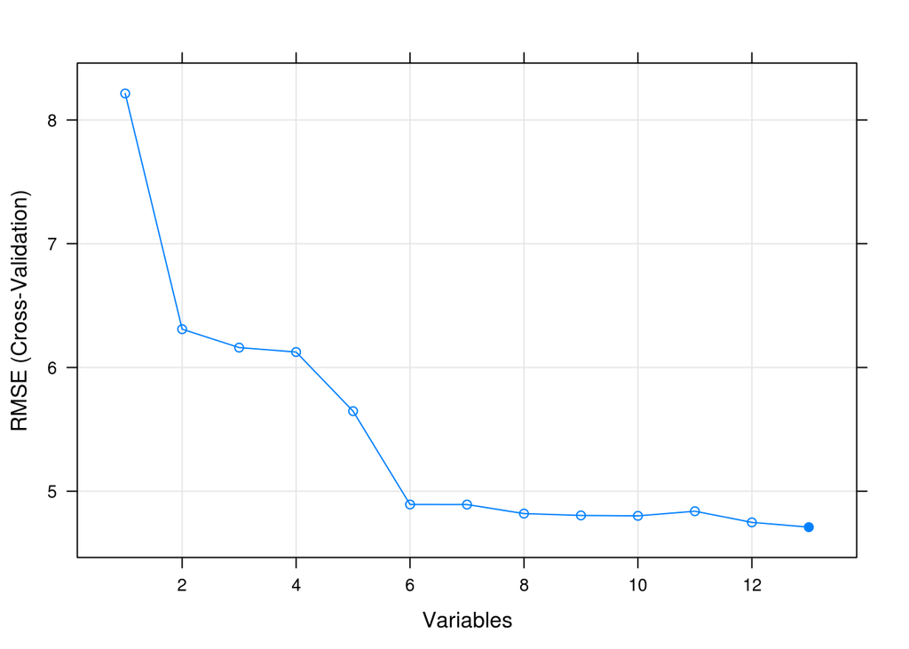

```r
plot(results, type=c("g", "o"))
```

Итоговые предикторы:

```r
predictors(results)
```

```
##  [1] "nox"     "rm"      "chas"    "dis"     "ptratio" "lstat"   "rad"
##  [8] "crim"    "zn"      "indus"   "tax"     "black"   "age"
```

Итоговая модель:

```r
summary(results$fit)
```

```
##
## Call:
## lm(formula = y ~ ., data = tmp)
##
## Residuals:
##      Min       1Q   Median       3Q      Max
## -16.0562  -2.5943  -0.6246   1.6235  24.9423
##
## Coefficients:
##               Estimate Std. Error t value Pr(>|t|)
## (Intercept)  35.837561   5.532087   6.478 2.81e-10 ***
## nox         -16.644405   4.175224  -3.986 8.01e-05 ***
## rm            3.614432   0.450735   8.019 1.26e-14 ***
## chas          2.772422   0.911918   3.040 0.002524 **
## dis          -1.441344   0.224532  -6.419 3.99e-10 ***
## ptratio      -0.908024   0.142741  -6.361 5.62e-10 ***
## lstat        -0.607631   0.057265 -10.611  < 2e-16 ***
## rad           0.306800   0.073621   4.167 3.80e-05 ***
## crim         -0.139932   0.036851  -3.797 0.000170 ***
## zn            0.049122   0.014517   3.384 0.000788 ***
## indus         0.039226   0.067539   0.581 0.561716
## tax          -0.011904   0.004156  -2.864 0.004405 **
## black         0.010149   0.002952   3.438 0.000648 ***
## age           0.007317   0.014659   0.499 0.617945
## ---
## Signif. codes:  0 '***' 0.001 '**' 0.01 '*' 0.05 '.' 0.1 ' ' 1
##
## Residual standard error: 4.655 on 389 degrees of freedom
## Multiple R-squared:  0.7503, Adjusted R-squared:  0.742
## F-statistic: 89.93 on 13 and 389 DF,  p-value: < 2.2e-16
```

Ошибка

```r
lmSelected.test.RSS <- sum((predict(results$fit, Boston.test)-Boston.test$medv)^2)
lmSelected.test.RSS
```

```
## [1] 2819.487
```

Исходная ошибка

```r
lm.test.RSS <- sum((predict(lm.fit, Boston.test)-Boston.test$medv)^2)
lm.test.RSS
```

```
## [1] 2819.487
```

Посмотрим на модели

```r
summary(lm.fit)
```

```
##
## Call:
## lm(formula = medv ~ ., data = Boston.train)
##
## Residuals:
##      Min       1Q   Median       3Q      Max
## -16.0562  -2.5943  -0.6246   1.6235  24.9423
##
## Coefficients:
##               Estimate Std. Error t value Pr(>|t|)
## (Intercept)  35.837561   5.532087   6.478 2.81e-10 ***
## crim         -0.139932   0.036851  -3.797 0.000170 ***
## zn            0.049122   0.014517   3.384 0.000788 ***
## indus         0.039226   0.067539   0.581 0.561716
## chas          2.772422   0.911918   3.040 0.002524 **
## nox         -16.644405   4.175224  -3.986 8.01e-05 ***
## rm            3.614432   0.450735   8.019 1.26e-14 ***
## age           0.007317   0.014659   0.499 0.617945
## dis          -1.441344   0.224532  -6.419 3.99e-10 ***
## rad           0.306800   0.073621   4.167 3.80e-05 ***
## tax          -0.011904   0.004156  -2.864 0.004405 **
## ptratio      -0.908024   0.142741  -6.361 5.62e-10 ***
## black         0.010149   0.002952   3.438 0.000648 ***
## lstat        -0.607631   0.057265 -10.611  < 2e-16 ***
## ---
## Signif. codes:  0 '***' 0.001 '**' 0.01 '*' 0.05 '.' 0.1 ' ' 1
##
## Residual standard error: 4.655 on 389 degrees of freedom
## Multiple R-squared:  0.7503, Adjusted R-squared:  0.742
## F-statistic: 89.93 on 13 and 389 DF,  p-value: < 2.2e-16
```

```r
summary(results$fit)
```

```
##
## Call:
## lm(formula = y ~ ., data = tmp)
##
## Residuals:
##      Min       1Q   Median       3Q      Max
## -16.0562  -2.5943  -0.6246   1.6235  24.9423
##
## Coefficients:
##               Estimate Std. Error t value Pr(>|t|)
## (Intercept)  35.837561   5.532087   6.478 2.81e-10 ***
## nox         -16.644405   4.175224  -3.986 8.01e-05 ***
## rm            3.614432   0.450735   8.019 1.26e-14 ***
## chas          2.772422   0.911918   3.040 0.002524 **
## dis          -1.441344   0.224532  -6.419 3.99e-10 ***
## ptratio      -0.908024   0.142741  -6.361 5.62e-10 ***
## lstat        -0.607631   0.057265 -10.611  < 2e-16 ***
## rad           0.306800   0.073621   4.167 3.80e-05 ***
## crim         -0.139932   0.036851  -3.797 0.000170 ***
## zn            0.049122   0.014517   3.384 0.000788 ***
## indus         0.039226   0.067539   0.581 0.561716
## tax          -0.011904   0.004156  -2.864 0.004405 **
## black         0.010149   0.002952   3.438 0.000648 ***
## age           0.007317   0.014659   0.499 0.617945
## ---
## Signif. codes:  0 '***' 0.001 '**' 0.01 '*' 0.05 '.' 0.1 ' ' 1
##
## Residual standard error: 4.655 on 389 degrees of freedom
## Multiple R-squared:  0.7503, Adjusted R-squared:  0.742
## F-statistic: 89.93 on 13 and 389 DF,  p-value: < 2.2e-16
```

Т.е. лучшей по ошибкам была признана модель со всеми переменными

Сравним с деревом:

```r
tree.test.RSS <- sum((predict(modelTree, Boston.test)-Boston.test$medv)^2)
```

По ошибкам мы получили:

| Метод | RSS (test set) |
| --- | --- |
| LM | 2819.487451 |
| LM with FS | 2819.487451 |
| Tree | 2267.4519645 |

- Какую модель выбрать?

**Ваша очередь** 1. Решите задачу предсказания диабета

```r
library(mlbench)
data(PimaIndiansDiabetes2)
library(dplyr)
Diabetes = na.omit(PimaIndiansDiabetes2)
```

Какие факторы вы бы выбрали? Почему? Попробуйте разные сочетания предикторов. Какие транформации можно использовать?

```r
set.seed(100)
test.ind = createDataPartition(Diabetes$diabetes, p = 0.2, list = FALSE)
Diabetes.test = Diabetes[test.ind,]
Diabetes.main = Diabetes[-test.ind,]

logMod = train(diabetes~glucose, data = Diabetes.main, method = "glm", family = binomial)

logPred = predict(logMod, Diabetes.test, type = "prob")
```

Как оценить качество модели?

2. Посмотрите, как подход RFE работает с классификацией. Решите задачу предсказания диабета с учетом RFE.

Попробуйте логистическую регрессию (rfeControl = rfeControl(functions=caretFuncs)). Какие переменные останутся в этом случае?

Общая схема

```r
set.seed(10)
results <- rfe(x = dplyr::select(<train data>, -diabetes),
               y= <train data>$diabetes,
               method = "glm",
               family = binomial(link = "logit"),
               sizes = c(2, 4, 7), # пример рассматриваемых подвыборок
               rfeControl = rfeControl(functions=caretFuncs,method = "cv", number = 1))
results
```

- Как сравнить модели?

### Еще один пример

Посмотрим на продажу (`Sales`) детских кресел

```r
library(ISLR)
data(Carseats)
```

```r
pander::pandoc.table(head(Carseats), split.tables=Inf)
```

| Sales | CompPrice | Income | Advertising | Population | Price | ShelveLoc | Age | Education | Urban | US |
| --- | --- | --- | --- | --- | --- | --- | --- | --- | --- | --- |
| 9.5 | 138 | 73 | 11 | 276 | 120 | Bad | 42 | 17 | Yes | Yes |
| 11.22 | 111 | 48 | 16 | 260 | 83 | Good | 65 | 10 | Yes | Yes |
| 10.06 | 113 | 35 | 10 | 269 | 80 | Medium | 59 | 12 | Yes | Yes |
| 7.4 | 117 | 100 | 4 | 466 | 97 | Medium | 55 | 14 | Yes | Yes |
| 4.15 | 141 | 64 | 3 | 340 | 128 | Bad | 38 | 13 | Yes | No |
| 10.81 | 124 | 113 | 13 | 501 | 72 | Bad | 78 | 16 | No | Yes |

Разбиение

```r
ind = createDataPartition(Carseats$Sales, p = 0.2, list = F)
trainCar = Carseats[-ind,]
testCar = Carseats[ind,]
```

Построим исходную модель

```r
lmCar = lm(Sales~., data = trainCar)
summary(lmCar)
```

```
##
## Call:
## lm(formula = Sales ~ ., data = trainCar)
##
## Residuals:
##     Min      1Q  Median      3Q     Max
## -2.9628 -0.6799  0.0035  0.6868  2.7015
##
## Coefficients:
##                   Estimate Std. Error t value Pr(>|t|)
## (Intercept)      5.4522810  0.6846169   7.964 3.27e-14 ***
## CompPrice        0.0933944  0.0046379  20.137  < 2e-16 ***
## Income           0.0161421  0.0020864   7.737 1.48e-13 ***
## Advertising      0.1234220  0.0123352  10.006  < 2e-16 ***
## Population       0.0001408  0.0004128   0.341    0.733
## Price           -0.0933709  0.0030090 -31.030  < 2e-16 ***
## ShelveLocGood    4.8681609  0.1770407  27.497  < 2e-16 ***
## ShelveLocMedium  1.9310584  0.1437981  13.429  < 2e-16 ***
## Age             -0.0460529  0.0035331 -13.035  < 2e-16 ***
## Education       -0.0224881  0.0223408  -1.007    0.315
## UrbanYes         0.0837303  0.1252248   0.669    0.504
## USYes           -0.2379675  0.1691877  -1.407    0.161
## ---
## Signif. codes:  0 '***' 0.001 '**' 0.01 '*' 0.05 '.' 0.1 ' ' 1
##
## Residual standard error: 1.023 on 307 degrees of freedom
## Multiple R-squared:  0.8677, Adjusted R-squared:  0.863
## F-statistic: 183.1 on 11 and 307 DF,  p-value: < 2.2e-16
```

Запустим алгоритм RFE (для примера - без кросс-валидации. По умолчанию используется bootstrap)

```r
set.seed(10)
results <- rfe(x = dplyr::select(trainCar, -Sales),
               y= trainCar$Sales,
               sizes = c(1:10),
               rfeControl = rfeControl(functions=lmFuncs))
```

Для того, чтобы функция `rfe()` работала, не выдавая ошибки “undefined column selected”, нужно преобразовать факторы в числа.

Для `Urban` и `US` (yes-no questions):

```r
Carseats$Urban <- as.numeric(Carseats$Urban) - 1
Carseats$US <- as.numeric(Carseats$US) - 1
```

Для `ShelveLoc` (фактор с тремя вариантами):

1 способ (не всегда подходящий)

```r
#Carseats$ShelveLocNew <- as.numeric(Carseats$ShelveLoc)
```

2 способ (dummy variables)

```r
temp <- model.matrix(~ ShelveLoc - 1, data=Carseats)
head(temp)
```

```
##   ShelveLocBad ShelveLocGood ShelveLocMedium
## 1            1             0               0
## 2            0             1               0
## 3            0             0               1
## 4            0             0               1
## 5            1             0               0
## 6            1             0               0
```

Т.к. третий фактор можно однозначно определить по значениям первых двух, то убираем один столбец из temp

```r
Carseats <- dplyr::select(Carseats, -ShelveLoc)
Carseats <- cbind(Carseats, temp[,-1])
```

Т.к. мы делали преобразования, не забываем разбить на тестовую и обучающую заново

```r
trainCarNew = Carseats[-ind,]
testCarNew = Carseats[ind,]
```

Запускаем RFE еще раз

```r
set.seed(10)
numVar= dim(trainCarNew)[2]-1
results <- rfe(x = dplyr::select(trainCarNew, -Sales),
               y= trainCarNew$Sales,
               sizes = 1:numVar,
               rfeControl = rfeControl(functions=lmFuncs))
```

Результаты

```r
results
```

```
##
## Recursive feature selection
##
## Outer resampling method: Bootstrapped (25 reps)
##
## Resampling performance over subset size:
##
##  Variables  RMSE Rsquared    MAE  RMSESD RsquaredSD   MAESD Selected
##          1 2.430   0.2295 2.0065 0.12468    0.05324 0.10417
##          2 2.333   0.2874 1.9116 0.12746    0.05781 0.09919
##          3 2.308   0.3032 1.8934 0.13084    0.05559 0.10928
##          4 2.268   0.3271 1.8518 0.17738    0.07916 0.15704
##          5 2.061   0.4330 1.6624 0.33741    0.15205 0.27736
##          6 1.679   0.6175 1.3514 0.35465    0.16581 0.28811
##          7 1.308   0.7757 1.0544 0.11587    0.04439 0.10183
##          8 1.173   0.8188 0.9442 0.13965    0.04680 0.11967
##          9 1.105   0.8402 0.8830 0.07577    0.02362 0.06028
##         10 1.049   0.8562 0.8406 0.05260    0.01821 0.04681        *
##         11 1.052   0.8554 0.8431 0.05457    0.01834 0.04705
##
## The top 5 variables (out of 10):
##    ShelveLocGood, ShelveLocMedium, US, Urban, Advertising
```

Сравнение моделей:

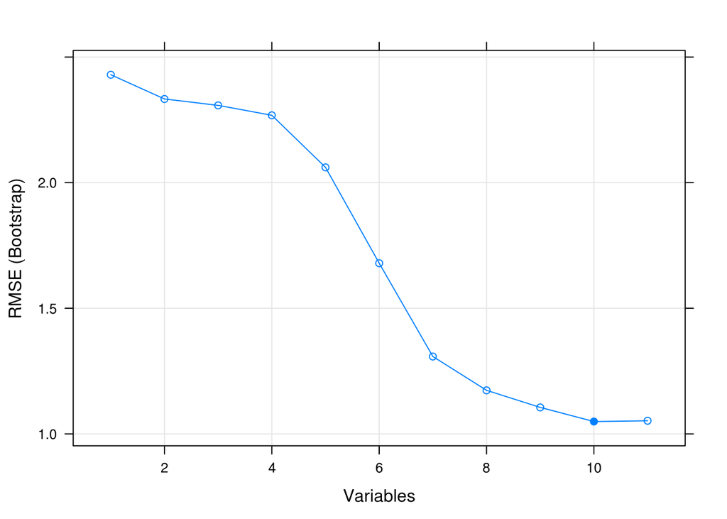

```r
plot(results, type=c("g", "o"))
```

Какая переменная выкинута?

```r
results$optVariables
```

```
##  [1] "ShelveLocGood"   "ShelveLocMedium" "US"
##  [4] "Urban"           "Advertising"     "CompPrice"
##  [7] "Price"           "Age"             "Education"
## [10] "Income"
```

```r
print("========")
```

```
## [1] "========"
```

```r
names(trainCarNew)[!names(trainCarNew) %in% results$optVariables]
```

```
## [1] "Sales"      "Population"
```

Ошибка на тестовой выборке

```r
lmCarRFE.test.RMSE <- sqrt(mean((predict(results$fit, testCarNew)-testCarNew$Sales)^2))
lmCarRFE.test.RMSE
```

```
## [1] 1.014924
```

```r
lmCar.test.RMSE <- sqrt(mean((predict(lmCar, testCar)-testCar$Sales)^2))
lmCar.test.RMSE
```

```
## [1] 1.013759
```

- Сравните с другими моделями

**Ваша очередь:**

Снова про классификацию: преобразуйте Sales в фактор

```r
Carseats$High = ifelse(Carseats$Sales>8, "yes", "no")
Carseats$High = factor(Carseats$High)
Carseats = dplyr::select(Carseats, -Sales)
```

Какие переменные останутся в этом случае?

Общая схема

```r
set.seed(10)
results <- rfe(x = dplyr::select(<train data>, -High),
               y= <train data>$High,
               method = "glm",
               family = binomial(link = "logit"),
               sizes = c(2, 4, 7), # пример рассматриваемых подвыборок
               rfeControl = rfeControl(functions=caretFuncs,method = "cv", number = 1))
results
```